# PROBLEM STATEMENT

A Chinese automobile company Geely Auto aspires to enter the Nigerian market by setting up its manufacturing unit and producing cars locally to compete with their Nigerian, US and European counterparts. They have contacted you, a Data Scientist to understand the factors on which the pricing of cars depends. Specifically, they want to understand the factors affecting the pricing of cars in the Nigerian market, since those may be very different from the Chinese market. The company wants to know:

- Which variables are significant in predicting the price of a car
- How well do those variables describe the price of a car Based on various market surveys, you have gathered a large data set of different types of cars across the Nigerian market.

# BUSINESS GOAL(Objective)

You are required to model the price of cars with the available independent variables. The management will use it to understand how exactly the prices vary with the independent variables. They can accordingly manipulate the design of the cars, the business strategy etc. to meet certain price levels. Further, the model will be a good way for management to understand the pricing dynamics of a new market

## Importing Libraries

```python
#Importing the required Libraries
import numpy as np
import pandas as pd
import matplotlib.pyplot as plt
%matplotlib inline
import seaborn as sns
from sklearn.model_selection import train_test_split
from sklearn import preprocessing
from sklearn import linear_model
from sklearn.linear_model import LinearRegression
from sklearn.metrics import r2_score,mean_squared_error,mean_absolute_error
from sklearn.ensemble import RandomForestRegressor
from sklearn.feature_selection import RFE
from sklearn.tree import DecisionTreeRegressor
from sklearn.preprocessing import LabelEncoder
from sklearn.model_selection import train_test_split,KFold,cross_val_score,GridSearchCV,RandomizedSearchCV
pd.set_option('display.max_columns', None)
pd.set_option('display.max_rows', None)
sns.set(rc={'figure.figsize':(8,8)})

import warnings
warnings.filterwarnings('ignore')
```

# DATA OVERVIEW

```python
df = pd.read_csv('CarPrice_data.csv')
```

```python
df.head()
```

|  | car_ID | symboling | CarName | fueltype | aspiration | doornumber | carbody | drivewheel | enginelocation | wheelbase | carlength | carwidth | carheight | curbweight | enginetype | cylindernumber | enginesize | fuelsystem | boreratio | stroke | compressionratio | horsepower | peakrpm | citympg | highwaympg | price |
| --- | --- | --- | --- | --- | --- | --- | --- | --- | --- | --- | --- | --- | --- | --- | --- | --- | --- | --- | --- | --- | --- | --- | --- | --- | --- | --- |
| 0 | 1 | 3 | alfa-romero giulia | gas | std | two | convertible | rwd | front | 88.6 | 168.8 | 64.1 | 48.8 | 2548 | dohc | four | 130 | mpfi | 3.47 | 2.68 | 9.0 | 111 | 5000 | 21 | 27 | 13495.0 |
| 1 | 2 | 3 | alfa-romero stelvio | gas | std | two | convertible | rwd | front | 88.6 | 168.8 | 64.1 | 48.8 | 2548 | dohc | four | 130 | mpfi | 3.47 | 2.68 | 9.0 | 111 | 5000 | 21 | 27 | 16500.0 |
| 2 | 3 | 1 | alfa-romero Quadrifoglio | gas | std | two | hatchback | rwd | front | 94.5 | 171.2 | 65.5 | 52.4 | 2823 | ohcv | six | 152 | mpfi | 2.68 | 3.47 | 9.0 | 154 | 5000 | 19 | 26 | 16500.0 |
| 3 | 4 | 2 | audi 100 ls | gas | std | four | sedan | fwd | front | 99.8 | 176.6 | 66.2 | 54.3 | 2337 | ohc | four | 109 | mpfi | 3.19 | 3.40 | 10.0 | 102 | 5500 | 24 | 30 | 13950.0 |
| 4 | 5 | 2 | audi 100ls | gas | std | four | sedan | 4wd | front | 99.4 | 176.6 | 66.4 | 54.3 | 2824 | ohc | five | 136 | mpfi | 3.19 | 3.40 | 8.0 | 115 | 5500 | 18 | 22 | 17450.0 |

## DATA CLEANING

### car_ID is obviously just a row identifier, So we can drop this variable.

```python
df=df.drop(['car_ID'],axis=1)
```

### The variable "CarName" contains the brand name and model. We actually need only the proper brand name. We will create a derived variable by splitting the CarName.

```python
df['CarBrand']=[x.split()[0].title() for x in df.CarName]
df['CarBrand'].head()
print(df.CarBrand.unique())
```

```
['Alfa-Romero' 'Audi' 'Bmw' 'Chevrolet' 'Dodge' 'Honda' 'Isuzu' 'Jaguar'
 'Maxda' 'Mazda' 'Buick' 'Mercury' 'Mitsubishi' 'Nissan' 'Peugeot'
 'Plymouth' 'Porsche' 'Porcshce' 'Renault' 'Saab' 'Subaru' 'Toyota'
 'Toyouta' 'Vokswagen' 'Volkswagen' 'Vw' 'Volvo']
```

```python
# vw is a short form of Volkswagen
# vokswagen is typo of Volkswagen
# Alfa-Romero is typo of Alfa-Romeo
# Toyouta is typo of Toyota
# Maxda is typo of Mazda
# Porcshce is typo of Porsche

# So correcting these two values
df.loc[df.CarBrand.isin(['Alfa-Romero']),'CarBrand']='Alfa-Romeo'
df.loc[df.CarBrand.isin(['Vw','Vokswagen']),'CarBrand']='Volkswagen'
df.loc[df.CarBrand.isin(['Toyouta']),'CarBrand']='Toyota'
df.loc[df.CarBrand.isin(['Maxda']),'CarBrand']='Mazda'
df.loc[df.CarBrand.isin(['Porcshce']),'CarBrand']='Porsche'

# Check the final values of Car Brands
print(df.CarBrand.unique())
print(df.CarBrand.value_counts())
```

```
['Alfa-Romeo' 'Audi' 'Bmw' 'Chevrolet' 'Dodge' 'Honda' 'Isuzu' 'Jaguar'
 'Mazda' 'Buick' 'Mercury' 'Mitsubishi' 'Nissan' 'Peugeot' 'Plymouth'
 'Porsche' 'Renault' 'Saab' 'Subaru' 'Toyota' 'Volkswagen' 'Volvo']
Toyota        32
Nissan        18
Mazda         17
Mitsubishi    13
Honda         13
Volkswagen    12
Subaru        12
Peugeot       11
Volvo         11
Dodge          9
Buick          8
Bmw            8
Audi           7
Plymouth       7
Saab           6
Porsche        5
Isuzu          4
Jaguar         3
Chevrolet      3
Alfa-Romeo     3
Renault        2
Mercury        1
Name: CarBrand, dtype: int64
```

```python
df.duplicated().sum()
```

```
0
```

```python
df.isna().sum()
```

```
symboling           0
CarName             0
fueltype            0
aspiration          0
doornumber          0
carbody             0
drivewheel          0
enginelocation      0
wheelbase           0
carlength           0
carwidth            0
carheight           0
curbweight          0
enginetype          0
cylindernumber      0
enginesize          0
fuelsystem          0
boreratio           0
stroke              0
compressionratio    0
horsepower          0
peakrpm             0
citympg             0
highwaympg          0
price               0
CarBrand            0
dtype: int64
```

```python
df['symboling']=df['symboling'].astype('str')
```

## Categorical columns

```python
categorical_cols=df.select_dtypes(include=['object']).columns
```

```python
df[categorical_cols].head(2)
```

|  | symboling | CarName | fueltype | aspiration | doornumber | carbody | drivewheel | enginelocation | enginetype | cylindernumber | fuelsystem | CarBrand |
| --- | --- | --- | --- | --- | --- | --- | --- | --- | --- | --- | --- | --- |
| 0 | 3 | alfa-romero giulia | gas | std | two | convertible | rwd | front | dohc | four | mpfi | Alfa-Romeo |
| 1 | 3 | alfa-romero stelvio | gas | std | two | convertible | rwd | front | dohc | four | mpfi | Alfa-Romeo |

## Numerical columns

```python
numerical_cols=df.select_dtypes(exclude=['object']).columns
```

```python
df[numerical_cols].head(2)
```

|  | wheelbase | carlength | carwidth | carheight | curbweight | enginesize | boreratio | stroke | compressionratio | horsepower | peakrpm | citympg | highwaympg | price |
| --- | --- | --- | --- | --- | --- | --- | --- | --- | --- | --- | --- | --- | --- | --- |
| 0 | 88.6 | 168.8 | 64.1 | 48.8 | 2548 | 130 | 3.47 | 2.68 | 9.0 | 111 | 5000 | 21 | 27 | 13495.0 |
| 1 | 88.6 | 168.8 | 64.1 | 48.8 | 2548 | 130 | 3.47 | 2.68 | 9.0 | 111 | 5000 | 21 | 27 | 16500.0 |

# Exploratory Data Analysis

```python
df.describe()
```

|  | wheelbase | carlength | carwidth | carheight | curbweight | enginesize | boreratio | stroke | compressionratio | horsepower | peakrpm | citympg | highwaympg | price |
| --- | --- | --- | --- | --- | --- | --- | --- | --- | --- | --- | --- | --- | --- | --- |
| count | 205.000000 | 205.000000 | 205.000000 | 205.000000 | 205.000000 | 205.000000 | 205.000000 | 205.000000 | 205.000000 | 205.000000 | 205.000000 | 205.000000 | 205.000000 | 205.000000 |
| mean | 98.756585 | 174.049268 | 65.907805 | 53.724878 | 2555.565854 | 126.907317 | 3.329756 | 3.255415 | 10.142537 | 104.117073 | 5125.121951 | 25.219512 | 30.751220 | 13276.710571 |
| std | 6.021776 | 12.337289 | 2.145204 | 2.443522 | 520.680204 | 41.642693 | 0.270844 | 0.313597 | 3.972040 | 39.544167 | 476.985643 | 6.542142 | 6.886443 | 7988.852332 |
| min | 86.600000 | 141.100000 | 60.300000 | 47.800000 | 1488.000000 | 61.000000 | 2.540000 | 2.070000 | 7.000000 | 48.000000 | 4150.000000 | 13.000000 | 16.000000 | 5118.000000 |
| 25% | 94.500000 | 166.300000 | 64.100000 | 52.000000 | 2145.000000 | 97.000000 | 3.150000 | 3.110000 | 8.600000 | 70.000000 | 4800.000000 | 19.000000 | 25.000000 | 7788.000000 |
| 50% | 97.000000 | 173.200000 | 65.500000 | 54.100000 | 2414.000000 | 120.000000 | 3.310000 | 3.290000 | 9.000000 | 95.000000 | 5200.000000 | 24.000000 | 30.000000 | 10295.000000 |
| 75% | 102.400000 | 183.100000 | 66.900000 | 55.500000 | 2935.000000 | 141.000000 | 3.580000 | 3.410000 | 9.400000 | 116.000000 | 5500.000000 | 30.000000 | 34.000000 | 16503.000000 |
| max | 120.900000 | 208.100000 | 72.300000 | 59.800000 | 4066.000000 | 326.000000 | 3.940000 | 4.170000 | 23.000000 | 288.000000 | 6600.000000 | 49.000000 | 54.000000 | 45400.000000 |

## UNIVARIATE ANALYSIS

```python
dat=pd.DataFrame(df['CarBrand'].value_counts()).reset_index().rename(columns={'index':'car_name','CarBrand': 'count'})
```

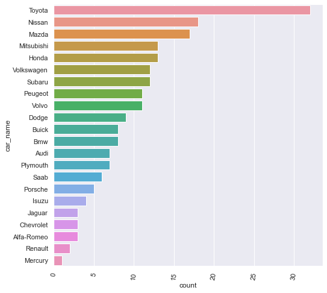

```python
plot = sns.barplot(y='car_name',x='count',data=dat)
plot=plt.setp(plot.get_xticklabels(), rotation=80)
```

### FUEL TYPE

```python
dat=pd.DataFrame(df['fueltype'].value_counts())
```

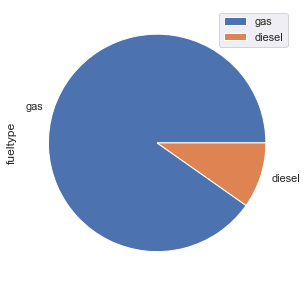

```python
plot = dat.plot.pie(y='fueltype', figsize=(5, 5))
```

We can therefore infer from the above that most cars uses gas

### ASPIRATION RATIO

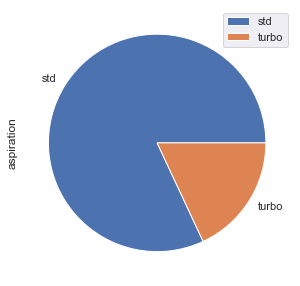

```python
dat=pd.DataFrame(df['aspiration'].value_counts())
plot = dat.plot.pie(y='aspiration', figsize=(5, 5))
```

Most of the cars have standard aspiration

### PRICE DISTRIBUTION OF CARS

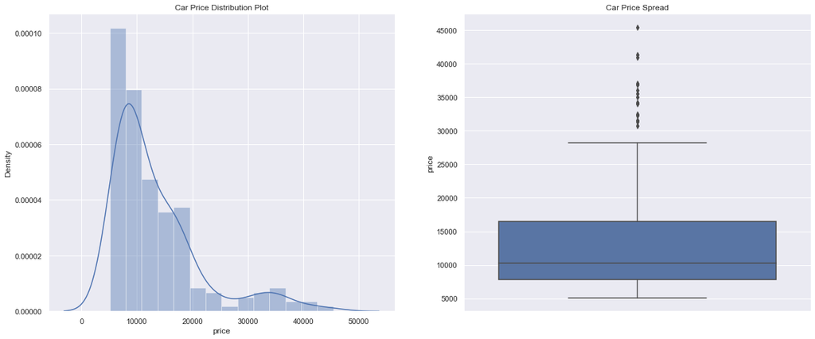

```python
plt.figure(figsize=(20,8))

plt.subplot(1,2,1)
plt.title('Car Price Distribution Plot')
sns.distplot(df.price)

plt.subplot(1,2,2)
plt.title('Car Price Spread')
sns.boxplot(y=df.price)

plt.show()
```

```python
print(df.price.describe(percentiles = [0.25,0.50,0.75,0.85,0.90,1]))
```

```
count      205.000000
mean     13276.710571
std       7988.852332
min       5118.000000
25%       7788.000000
50%      10295.000000
75%      16503.000000
85%      18500.000000
90%      22563.000000
100%     45400.000000
max      45400.000000
Name: price, dtype: float64
```

1) The plot seemed to be right-skewed, meaning that the most prices in the dataset are low(Below 15,000).

2) There is a significant difference between the mean and the median of the price distribution.

3) The data points are far spread out from the mean, which indicates a high variance in the car prices.(85% of the prices are below 18,500, whereas the remaining 15% are between 18,500 and 45,400).

### SYMBOLING

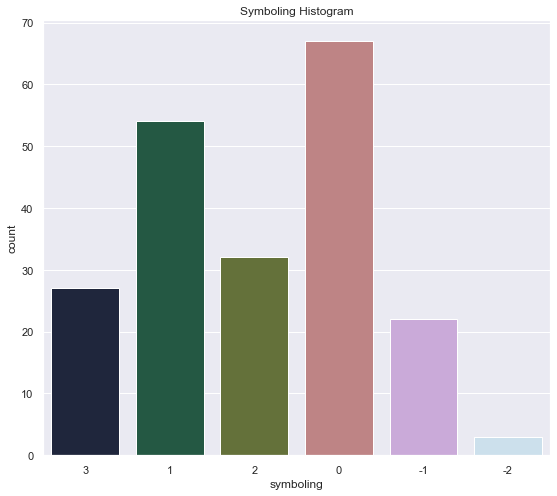

```python
plt.figure(figsize=(20,8))

plt.subplot(1,2,1)
plt.title('Symboling Histogram')
sns.countplot(df.symboling, palette=("cubehelix"))
```

It seems that the symboling with 0 and 1 values have high number of rows (i.e. They are most sold).

### DOOR NUMBER

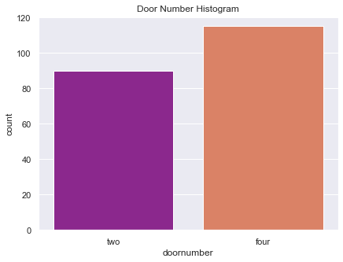

```python
plt.figure(figsize=(15,5))

plt.subplot(1,2,1)
plt.title('Door Number Histogram')
sns.countplot(df.doornumber, palette=("plasma"))
```

More than 100 cars has four doors and below 100 cars has 2 doors

### ENGINE LOCATION

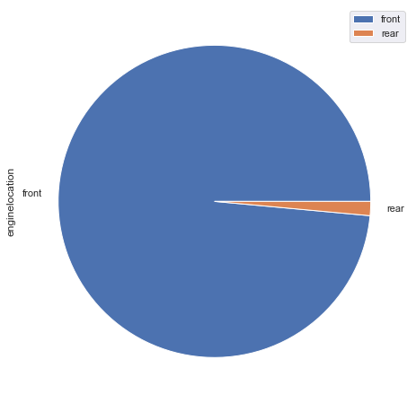

```python
dat=pd.DataFrame(df['enginelocation'].value_counts())
plot = dat.plot.pie(y='enginelocation', figsize=(8, 8))
```

Only very few cars have rear engine

### ENGINE TYPE

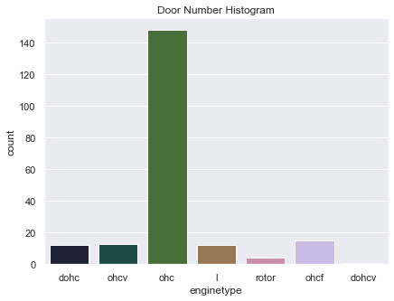

```python
plt.figure(figsize=(15,5))

plt.subplot(1,2,1)
plt.title('Door Number Histogram')
sns.countplot(df.enginetype, palette=("cubehelix"))
```

Maximum number of engine type are of 'ohc'

### CYLINDER NUMBER

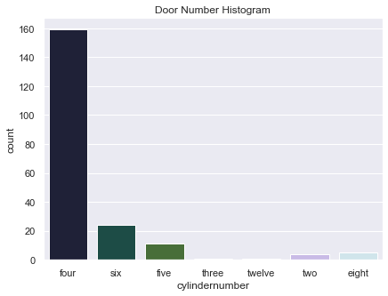

```python
plt.figure(figsize=(15,5))

plt.subplot(1,2,1)
plt.title('Door Number Histogram')
sns.countplot(df.cylindernumber, palette=("cubehelix"))
```

maximum cars are of four cylinder number

### DRIVE WHEEL

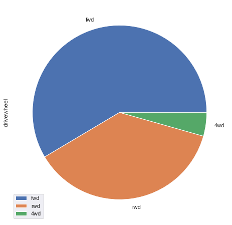

```python
dat=pd.DataFrame(df['drivewheel'].value_counts())
plot = dat.plot.pie(y='drivewheel', figsize=(8, 8))
```

Maximum cars has fwd drive wheel

### CAR BODY

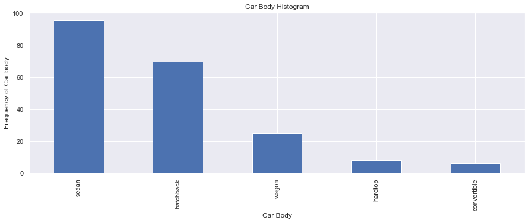

```python
"""plt.figure(figsize=(15,5))

plt.subplot(1,2,1)
plt.title('Door Number Histogram')
sns.countplot(df.carbody, palette=("plasma"))"""

plt.figure(figsize=(15,5))
plt1 = df.carbody.value_counts().plot(kind='bar')
plt.title('Car Body Histogram')
plt1.set(xlabel = 'Car Body', ylabel='Frequency of Car body')

plt.show()
```

Sedan is the most prefered Car Body followed by hatchback

## BIVARIATE ANALYSIS

### FUEL TYPE VS PRICE

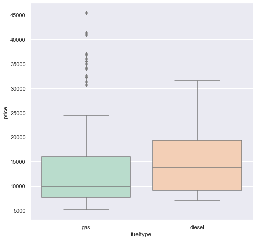

```python
sns.boxplot(x = 'fueltype', y = 'price', data = df,palette='Pastel2')
```

### SYMBOLING VS PRICE

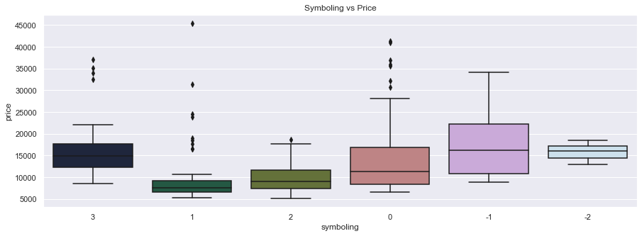

```python
plt.figure(figsize=(15,5))
plt.title('Symboling vs Price')
sns.boxplot(x=df.symboling, y=df.price, palette=("cubehelix"))

plt.show()
```

The cars with -1 symboling seems to be high priced (as it makes sense too, insurance risk rating -1 is quite good). There seems to be a dip in price at symboling 1.

### ASPIRATION VS PRICE

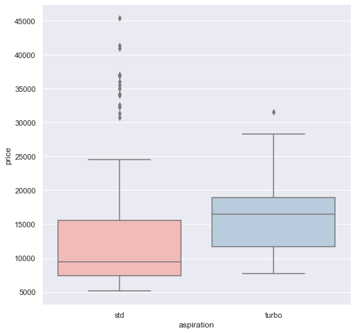

```python
sns.boxplot(x = 'aspiration', y = 'price', data = df,palette='Pastel1')
```

Price of turbo is higher in compared to std , although there are some outliers in std price

### DOOR NUMBER VS PRICE

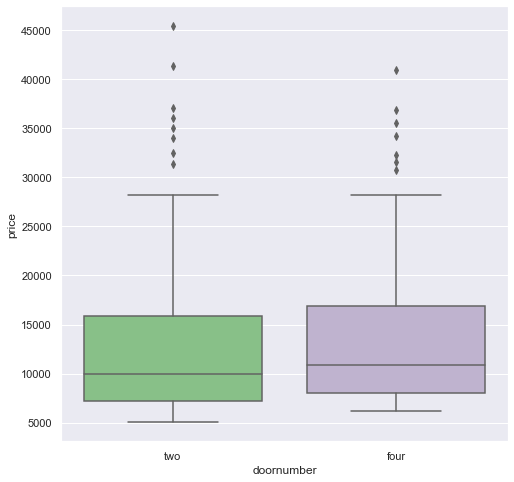

```python
sns.boxplot(x = 'doornumber', y = 'price', data = df,palette='Accent')
```

### CAR BODY VS PRICE

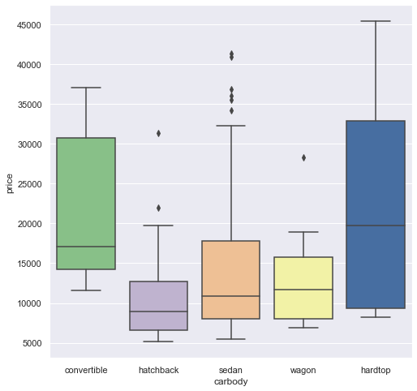

```python
sns.boxplot(x = 'carbody', y = 'price', data = df,palette='Accent')
```

price of hardtop is very high compare to others

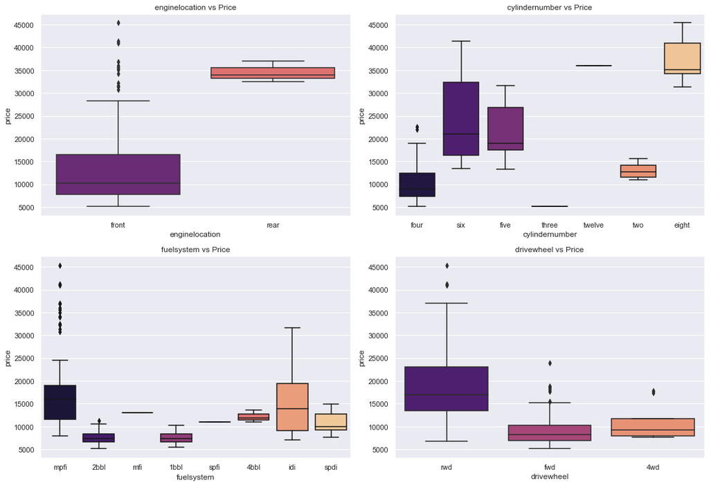

```python
def plot_count(x,fig):
    plt.subplot(4,2,fig)
    #plt.title(x+' Histogram')
    #sns.countplot(df[x],palette=("magma"))
    #plt.subplot(4,2,(fig+1))
    plt.title(x+' vs Price')
    sns.boxplot(x=df[x], y=df.price, palette=("magma"))

plt.figure(figsize=(15,20))

plot_count('enginelocation', 1)
plot_count('cylindernumber', 2)
plot_count('fuelsystem', 3)
plot_count('drivewheel', 4)

plt.tight_layout()
```

For Fuel system VS price mpfi and idi are having the highest price range

For driveWheel VS price most high ranged cars seem to prefer rwd drivewheel.

### ENGINE TYPE VS PRICE

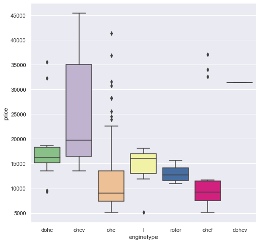

```python
sns.boxplot(x = 'enginetype', y = 'price', data = df,palette='Accent')
```

Price range of ohcv engine cars are quite high in compare to others

### For the Numerical Features

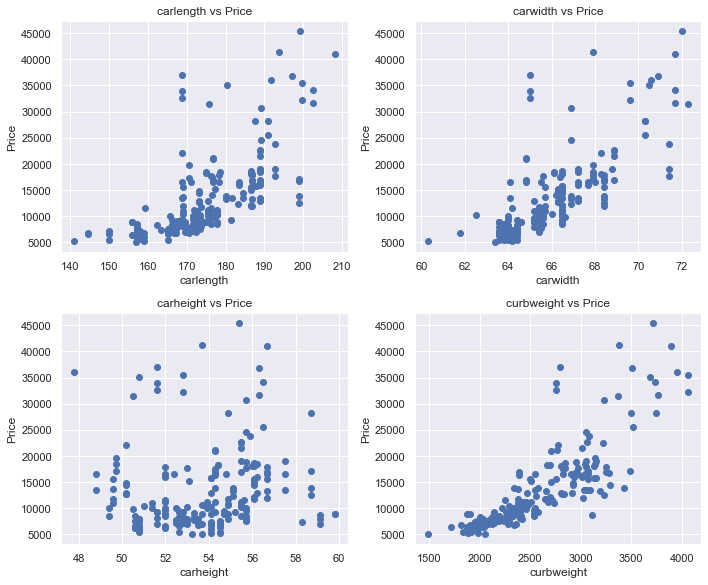

```python
def scatter(x,fig):
    plt.subplot(5,2,fig)
    plt.scatter(df[x],df['price'])
    plt.title(x+' vs Price')
    plt.ylabel('Price')
    plt.xlabel(x)

plt.figure(figsize=(10,20))

scatter('carlength', 1)
scatter('carwidth', 2)
scatter('carheight', 3)
scatter('curbweight', 4)

plt.tight_layout()
```

- Carwidth, carlength and curbweight seems to have a poitive correlation with price.
- Carheight doesn't show any significant trend with price

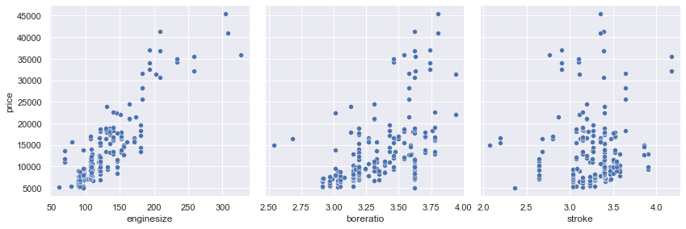

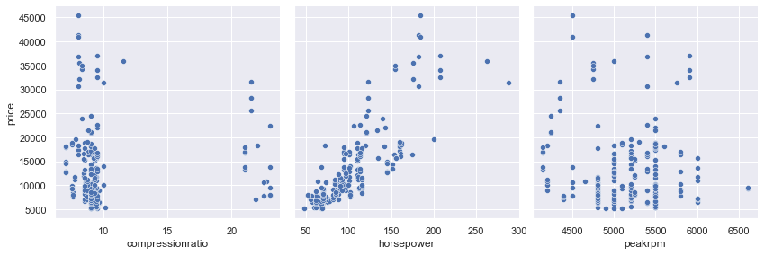

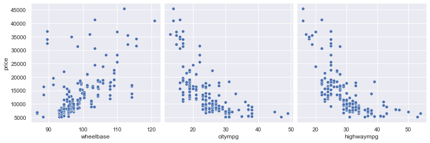

```python
def pp(x,y,z):
    sns.pairplot(df, x_vars=[x,y,z], y_vars='price',height=4, aspect=1, kind='scatter')
    plt.show()

pp('enginesize', 'boreratio', 'stroke')
pp('compressionratio', 'horsepower', 'peakrpm')
pp('wheelbase', 'citympg', 'highwaympg')
```

- Enginesize, boreratio, horsepower, wheelbase - seem to have a significant positive correlation with price.
- Citympg, highwaympg - seem to have a significant negative correlation with price.

```python
#sns.pairplot(df)
```

### CORRELATION MATRIX

```python
df[numerical_cols].corr()
```

|  | wheelbase | carlength | carwidth | carheight | curbweight | enginesize | boreratio | stroke | compressionratio | horsepower | peakrpm | citympg | highwaympg | price |
| --- | --- | --- | --- | --- | --- | --- | --- | --- | --- | --- | --- | --- | --- | --- |
| wheelbase | 1.000000 | 0.874587 | 0.795144 | 0.589435 | 0.776386 | 0.569329 | 0.488750 | 0.160959 | 0.249786 | 0.353294 | -0.360469 | -0.470414 | -0.544082 | 0.577816 |
| carlength | 0.874587 | 1.000000 | 0.841118 | 0.491029 | 0.877728 | 0.683360 | 0.606454 | 0.129533 | 0.158414 | 0.552623 | -0.287242 | -0.670909 | -0.704662 | 0.682920 |
| carwidth | 0.795144 | 0.841118 | 1.000000 | 0.279210 | 0.867032 | 0.735433 | 0.559150 | 0.182942 | 0.181129 | 0.640732 | -0.220012 | -0.642704 | -0.677218 | 0.759325 |
| carheight | 0.589435 | 0.491029 | 0.279210 | 1.000000 | 0.295572 | 0.067149 | 0.171071 | -0.055307 | 0.261214 | -0.108802 | -0.320411 | -0.048640 | -0.107358 | 0.119336 |
| curbweight | 0.776386 | 0.877728 | 0.867032 | 0.295572 | 1.000000 | 0.850594 | 0.648480 | 0.168790 | 0.151362 | 0.750739 | -0.266243 | -0.757414 | -0.797465 | 0.835305 |
| enginesize | 0.569329 | 0.683360 | 0.735433 | 0.067149 | 0.850594 | 1.000000 | 0.583774 | 0.203129 | 0.028971 | 0.809769 | -0.244660 | -0.653658 | -0.677470 | 0.874145 |
| boreratio | 0.488750 | 0.606454 | 0.559150 | 0.171071 | 0.648480 | 0.583774 | 1.000000 | -0.055909 | 0.005197 | 0.573677 | -0.254976 | -0.584532 | -0.587012 | 0.553173 |
| stroke | 0.160959 | 0.129533 | 0.182942 | -0.055307 | 0.168790 | 0.203129 | -0.055909 | 1.000000 | 0.186110 | 0.080940 | -0.067964 | -0.042145 | -0.043931 | 0.079443 |
| compressionratio | 0.249786 | 0.158414 | 0.181129 | 0.261214 | 0.151362 | 0.028971 | 0.005197 | 0.186110 | 1.000000 | -0.204326 | -0.435741 | 0.324701 | 0.265201 | 0.067984 |
| horsepower | 0.353294 | 0.552623 | 0.640732 | -0.108802 | 0.750739 | 0.809769 | 0.573677 | 0.080940 | -0.204326 | 1.000000 | 0.131073 | -0.801456 | -0.770544 | 0.808139 |
| peakrpm | -0.360469 | -0.287242 | -0.220012 | -0.320411 | -0.266243 | -0.244660 | -0.254976 | -0.067964 | -0.435741 | 0.131073 | 1.000000 | -0.113544 | -0.054275 | -0.085267 |
| citympg | -0.470414 | -0.670909 | -0.642704 | -0.048640 | -0.757414 | -0.653658 | -0.584532 | -0.042145 | 0.324701 | -0.801456 | -0.113544 | 1.000000 | 0.971337 | -0.685751 |
| highwaympg | -0.544082 | -0.704662 | -0.677218 | -0.107358 | -0.797465 | -0.677470 | -0.587012 | -0.043931 | 0.265201 | -0.770544 | -0.054275 | 0.971337 | 1.000000 | -0.697599 |
| price | 0.577816 | 0.682920 | 0.759325 | 0.119336 | 0.835305 | 0.874145 | 0.553173 | 0.079443 | 0.067984 | 0.808139 | -0.085267 | -0.685751 | -0.697599 | 1.000000 |

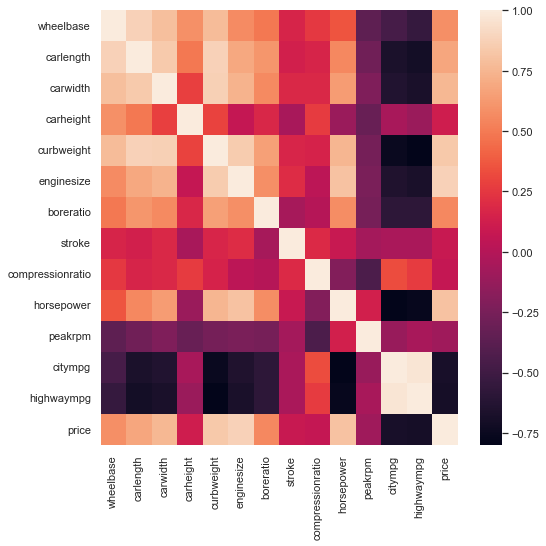

```python
sns.heatmap(df[numerical_cols].corr())
```

- wheelbase has high positive correlation with carlength,carwidth and curbweight
- carlength has high postive correlation with curbweight
- carlength has negative correlation with highwaympg
- carwidth has high postive correlation with curbweight and engine size
- enginesize has high positive correlation with horsepower
- curbweight has high positive correlation with engine size and horse power, negative correlation with highwaympg
- horsepower has negative correlation with citympg and highwaympg
- citympg and highwaympg are highly correlated

## Feature Selection

```python
X=df[numerical_cols].drop('price',axis=1)
y=df['price']
```

### Recursive feature elimination (RFE) with random forest

```python
X = df.apply(lambda col: preprocessing.LabelEncoder().fit_transform(col))
X=X.drop(['CarName','price'],axis=1)
y=df['price']
```

```python
# Create the RFE object and rank each pixel
clf_rf_3 = RandomForestRegressor()
rfe = RFE(estimator=clf_rf_3, n_features_to_select=15, step=1)
rfe = rfe.fit(X, y)
print('Chosen best 15 feature by rfe:',X.columns[rfe.support_])
```

```
Chosen best 15 feature by rfe: Index(['carbody', 'wheelbase', 'carlength', 'carwidth', 'carheight',
       'curbweight', 'enginesize', 'boreratio', 'stroke', 'compressionratio',
       'horsepower', 'peakrpm', 'citympg', 'highwaympg', 'CarBrand'],
      dtype='object')
```

```python
features=list(X.columns[rfe.support_])
```

# Data Modelling and Evaluation

```python
x = X[features]
y = df.price
x_train,x_test,y_train,y_test = train_test_split(x,y, random_state = 0)
```

### Using Linear Regression

```python
lreg = linear_model.LinearRegression()
lreg.fit(x_train,y_train)
#y_train_pred = lreg.predict(x_train)
y_test_pred = lreg.predict(x_test)
y_test_pred
```

```
array([ 6968.39447042, 20225.78397077, 17259.52133217,  5231.27179812,
       11614.38156497, 14437.66335574,  6084.46466192,  4748.48168786,
       23818.60512059,  8297.2669119 , 22018.38711667, 32024.55230983,
       11554.28787966, 14396.73841801,  7551.69486312, 13900.97891813,
        7978.88521035, 19458.54567732, 10477.23965231,  5825.124687  ,
        8854.59403548, 17087.81282705,  8616.76680201, 13973.17169499,
       22466.5512177 ,  6524.34030934,  6148.61565788, 16191.36213749,
        6978.29484908,  5948.38253445,  7751.43319792,  7460.74006482,
       23603.23875032,  9057.16318545,  5984.47892288, 25552.85969591,
        8969.27317848, 18560.56828946,  7595.1148472 , 30287.86034921,
        7515.59847469, 17712.8077152 , 29981.26878588, 17839.161087  ,
       10276.56321214,  5108.38893819,  7154.98184425, 15244.47877369,
        8948.65008992,  7805.57778056, 21078.56706054,  5351.69448876])
```

```python
lreg.score(x_test,y_test)
```

```
0.8034568463752468
```

### Using Decision Tree Regressor

```python
dt_regressor = DecisionTreeRegressor(random_state=0)
dt_regressor.fit(x_train,y_train)
y_train_pred = dt_regressor.predict(x_train)
y_test_pred = dt_regressor.predict(x_test)
dt_regressor.score(x_test,y_test)
```

```
0.8591188137491917
```

### Random Forest Regressor

```python
Rf = RandomForestRegressor(n_estimators = 15,
                              criterion = 'mse',
                              random_state = 20,
                              n_jobs = -1)
Rf.fit(x_train,y_train)
Rf_train_pred = Rf.predict(x_train)
Rf_test_pred = Rf.predict(x_test)


r2_score(y_test,Rf_test_pred)
```

```
0.9129541993611439
```

# CONCLUSION & INSIGHTS

Having applied three models that Linear Regression, Decision Tree Regressor and Random Forest Regressor and subjecting each to accuracy evaluation, we can now have a satisfied model from the random forest Regressor model based on its higher accuarcy performance to predict the prices of cars by Geely Auto in Nigerian market.